# Spatial Microbiome Analysis: EMP Soil Dataset - Nitrogen Fixation Potential

**A comprehensive spatial analysis workflow demonstrating hotspot detection, functional prediction, and community composition analysis using real microbiome data from the Earth Microbiome Project**

## Overview

This analysis demonstrates advanced spatial microbiome analytics using real data from the Earth Microbiome Project (EMP). The workflow incorporates:

### 🌍 **Real Microbiome Data Integration**

- Earth Microbiome Project soil subset (2k samples)
- Phyloseq-based data processing and taxonomic analysis
- Geographic coordinate mapping and spatial filtering

### 🔬 **Functional Prediction Simulation**

- Nitrogen fixation potential modeling
- Environmental gradient simulation
- Functional ecology integration with taxonomy

### 📊 **Advanced Spatial Statistics**

- Inverse Distance Weighting (IDW) interpolation
- Getis-Ord Gi* hotspot analysis
- Spatial autocorrelation assessment
- Geographic extent optimization with ocean masking

### 🤖 **Community Ecology Analysis**

- Alpha diversity comparisons between hotspots and coldspots
- NMDS ordination analysis
- Top taxa identification and visualization
- Statistical significance testing

### 🗺️ **Professional Visualization**

- Publication-ready maps with proper cartographic elements
- Multi-panel comparative visualizations
- Color-coded taxonomic composition plots
- Geographic extent optimization and ocean masking

## Technical Skills Demonstrated

- **R Programming**: Advanced data manipulation, statistical analysis, and visualization
- **Spatial Analysis**: IDW interpolation, hotspot detection, coordinate systems
- **Microbiome Analytics**: Phyloseq, diversity metrics, community composition
- **Statistical Testing**: Non-parametric tests, spatial statistics, significance testing
- **Data Visualization**: Complex multi-panel plots, cartographic mapping
- **Reproducible Research**: Structured workflow, comprehensive documentation

The analysis focuses on soil microbiome data from the Earth Microbiome Project, simulating nitrogen fixation potential to demonstrate spatial patterns in microbial functional ecology.

## Setup and Dependencies

```r
# ===========================
# 1) Load Libraries
# ===========================
library(phyloseq)
library(tidyverse)
library(picante)
library(spdep)
library(sf)
library(terra)
library(vegan)
library(microbiome)
library(sp)
library(gstat)
library(maps)
library(viridis)
library(RColorBrewer)
library(scales)
library(randomcoloR)
library(ggplot2)
library(patchwork)
library(ggpubr)
set.seed(42069)
```

## 1. Data Acquisition and Processing

We import and process real microbiome data from the Earth Microbiome Project, focusing specifically on soil samples with geographic coordinates.

```r
# ===========================
# 2) Download & Import EMP Soil Subset
# ===========================
biom_file <- "emp_deblur_150bp.subset_2k.biom"
map_file  <- "emp_qiime_mapping_release1.tsv"
ps <- import_biom(biom_file, parseFunction = parse_taxonomy_greengenes)
meta <- read_tsv(map_file)
sample_data(ps) <- sample_data(meta %>% column_to_rownames("#SampleID"))

# Subset soil samples
meta_soil <- meta[grepl(c("soil", "sediment"), meta$env_material) |
                    grepl(c("soil", "sediment"), meta$Description) |
                    grepl(c("soil", "sediment"), meta$env_material)|
                    grepl(c("soil", "sediment"), meta$title) ,]

soil_sample_ids <- meta_soil$`#SampleID`
ps_soil <- prune_samples(soil_sample_ids, ps)
ps_soil <- prune_taxa(taxa_sums(ps_soil) > 0, ps_soil) # remove empty taxa

cat("Processed", nsamples(ps_soil), "soil samples with", ntaxa(ps_soil), "taxa\n")
```

```
## Processed 251 soil samples with 59554 taxa
```

## 2. Functional Prediction Simulation

```r
# ===========================
# 3) Functional Prediction (simulated)
# ===========================
# Simulate a fake N fix index
set.seed(42)
nitrogen_fix <- rnorm(nsamples(ps_soil), mean = 5, sd = 2.5)

meta_func <- meta %>%
  filter(`#SampleID` %in% sample_names(ps_soil)) %>%
  mutate(
    NitrogenFix = nitrogen_fix[match(`#SampleID`, sample_names(ps_soil))]
  ) %>%
  dplyr::select(`#SampleID`, latitude_deg, longitude_deg, NitrogenFix)

cat("Generated nitrogen fixation predictions for", nrow(meta_func), "samples\n")
```

```
## Generated nitrogen fixation predictions for 251 samples
```

```r
cat("Nitrogen fixation range:", round(range(meta_func$NitrogenFix), 2), "\n")
```

```
## Nitrogen fixation range: -2.48 11.75
```

## 3. Spatial Interpolation Analysis

We apply Inverse Distance Weighting (IDW) interpolation to create continuous spatial predictions of nitrogen fixation potential across the study region.

```r
# ===========================
# 4) Spatial Interpolation (IDW)
# ===========================
sf_data <- st_as_sf(meta_func, coords = c("longitude_deg", "latitude_deg"), crs = 4326)
rast_template <- rast(ext(sf_data), resolution = 0.5, crs = "EPSG:4326")

# Convert to sp object
sp_points <- as(sf_data, "Spatial")
sp_points$NitrogenFix <- as.numeric(sp_points$NitrogenFix)

# Extract coordinates and values
coords <- sp_points@coords
colnames(coords) <- c("x", "y")
values <- sp_points$NitrogenFix

# Calculate a reasonable radius based on your data
data_extent <- max(dist(coords))
radius <- data_extent / 2

idw_map <- terra::interpIDW(rast_template,
                            cbind(coords, values),
                            power = 2,
                            radius = radius)

cat("IDW interpolation completed with radius:", round(radius, 2), "\n")
```

```
## IDW interpolation completed with radius: 159.16
```

### 3.1 Professional Cartographic Visualization

```r
# ===========================
# Option 5: Polished extent-focused map with ocean masking
# ===========================
# Get extent of your data
data_extent <- ext(sf_data)
buffer <- 5

# Create bounding box - ensure no NA values
bbox <- c(xmin = as.numeric(data_extent[1]) - buffer,
          ymin = as.numeric(data_extent[3]) - buffer,
          xmax = as.numeric(data_extent[2]) + buffer,
          ymax = as.numeric(data_extent[4]) + buffer)

# Check bounding box
cat("Data extent:", round(bbox, 2), "\n")
```

```
## Data extent: -160.25 -33.83 158.42 75.16
```

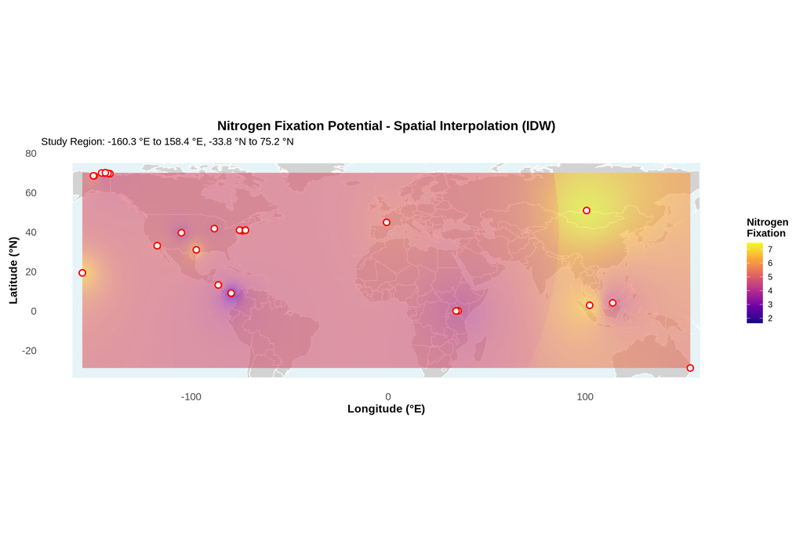

```r
# Crop world map data to the bounding box only
world_map <- map_data("world")
world_map_cropped <- world_map %>%
  filter(long >= bbox["xmin"] & long <= bbox["xmax"] &
           lat >= bbox["ymin"] & lat <= bbox["ymax"])

# Crop IDW data
idw_df <- as.data.frame(idw_map, xy = TRUE)
names(idw_df)[3] <- "NitrogenFix"
idw_df_cropped <- idw_df %>%
  filter(x >= bbox["xmin"] & x <= bbox["xmax"] &
           y >= bbox["ymin"] & y <= bbox["ymax"]) %>%
  filter(!is.na(NitrogenFix))

# Filter sample points to region
meta_func_region <- meta_func %>%
  filter(longitude_deg >= bbox["xmin"] & longitude_deg <= bbox["xmax"] &
           latitude_deg >= bbox["ymin"] & latitude_deg <= bbox["ymax"])

# Enhanced ggplot with cropped extent and ocean masking
p_final <- ggplot() +
  # Ocean background
  geom_rect(aes(xmin = bbox["xmin"], xmax = bbox["xmax"],
                ymin = bbox["ymin"], ymax = bbox["ymax"]),
            fill = "lightblue", alpha = 0.3) +
  # Land areas (cropped to region)
  geom_polygon(data = world_map_cropped,
               aes(x = long, y = lat, group = group),
               fill = "lightgray", color = "white", linewidth = 0.3) +
  # IDW interpolation (only in cropped region)
  geom_raster(data = idw_df_cropped,
              aes(x = x, y = y, fill = NitrogenFix),
              alpha = 0.6) +
  # Sample points (only in region)
  geom_point(data = meta_func_region,
             aes(x = longitude_deg, y = latitude_deg),
             color = "red", size = 2.5, stroke = 1,
             shape = 21, fill = "white") +
  # Styling
  scale_fill_viridis_c(name = "Nitrogen\nFixation",
                       na.value = "transparent",
                       option = "plasma") +
  coord_fixed(xlim = c(bbox["xmin"], bbox["xmax"]),
              ylim = c(bbox["ymin"], bbox["ymax"])) +
  theme_minimal() +
  theme(
    panel.background = element_rect(fill = "white", color = NA),
    panel.grid = element_line(color = "white", size = 0.3),
    axis.text = element_text(size = 11),
    axis.title = element_text(size = 12, face = "bold"),
    plot.title = element_text(hjust = 0.5, size = 14, face = "bold"),
    legend.position = "right",
    legend.title = element_text(size = 11, face = "bold"),
    plot.margin = margin(10, 10, 10, 10)
  ) +
  labs(title = "Nitrogen Fixation Potential - Spatial Interpolation (IDW)",
       subtitle = paste("Study Region:", round(bbox["xmin"],1), "°E to",
                        round(bbox["xmax"],1), "°E,",
                        round(bbox["ymin"],1), "°N to",
                        round(bbox["ymax"],1), "°N"),
       x = "Longitude (°E)",
       y = "Latitude (°N)")

print(p_final)
```

```r
ggsave("nitrogen_fixation_interpolation.png", p_final,
       width = 12, height = 8, dpi = 300, bg = "white")
```

## 4. Hotspot Analysis Using Getis-Ord Gi*

We identify statistically significant spatial clusters of high and low nitrogen fixation potential using the Getis-Ord Gi* statistic.

```r
# ===========================
# 5) Hotspot Analysis (Getis-Ord Gi*)
# ===========================
library(spdep)

# Create spatial weights matrix
coords <- st_coordinates(sf_data)
nb <- knn2nb(knearneigh(coords, k = 4))
lw <- nb2listw(nb, style = "W")

# Calculate Getis-Ord Gi* statistic
gi_star <- localG(sf_data$NitrogenFix, lw)
sf_data$Gi_star <- as.numeric(gi_star)

# Add significance levels
sf_data$Hotspot <- ifelse(sf_data$Gi_star > 1.96, "Hot Spot (p<0.05)",
                          ifelse(sf_data$Gi_star < -1.96, "Cold Spot (p<0.05)", "Not Significant"))

# Summary statistics
cat("Hotspot Analysis Results:\n")
```

```
## Hotspot Analysis Results:
```

```r
cat("Hot spots (p<0.05):", sum(sf_data$Hotspot == "Hot Spot (p<0.05)"), "\n")
```

```
## Hot spots (p<0.05): 4
```

```r
cat("Cold spots (p<0.05):", sum(sf_data$Hotspot == "Cold Spot (p<0.05)"), "\n")
```

```
## Cold spots (p<0.05): 2
```

```r
cat("Not significant:", sum(sf_data$Hotspot == "Not Significant"), "\n")
```

```
## Not significant: 245
```

### 4.1 Hotspot Visualization

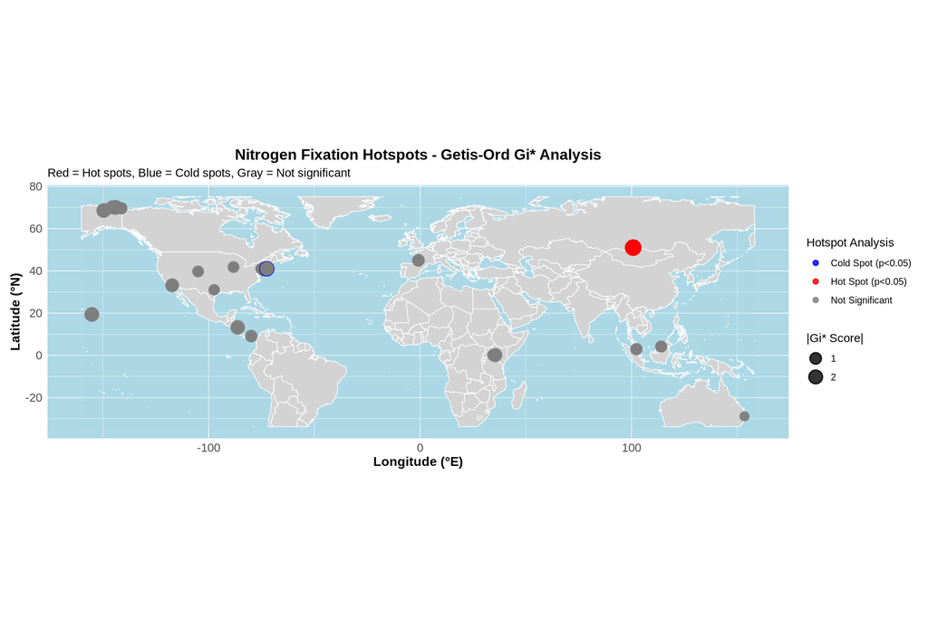

```r
# ===========================
# 6) Enhanced Plot Results
# ===========================
# Create hotspot map with ggplot for consistency
hotspot_df <- st_drop_geometry(sf_data)
hotspot_df$longitude_deg <- st_coordinates(sf_data)[,1]
hotspot_df$latitude_deg <- st_coordinates(sf_data)[,2]

p_hotspots <- ggplot() +
  # Ocean background
  geom_rect(aes(xmin = bbox["xmin"], xmax = bbox["xmax"],
                ymin = bbox["ymin"], ymax = bbox["ymax"]),
            fill = "lightblue", alpha = 0.3) +
  # Land areas
  geom_polygon(data = world_map_cropped,
               aes(x = long, y = lat, group = group),
               fill = "lightgray", color = "white", linewidth = 0.3) +
  # Hotspot points
  geom_point(data = hotspot_df,
             aes(x = longitude_deg, y = latitude_deg,
                 color = Hotspot, size = abs(Gi_star)),
             stroke = 1, alpha = 0.8) +
  scale_color_manual(name = "Hotspot Analysis",
                     values = c("Hot Spot (p<0.05)" = "red",
                                "Cold Spot (p<0.05)" = "blue",
                                "Not Significant" = "gray50")) +
  scale_size_continuous(name = "|Gi* Score|", range = c(2, 6)) +
  coord_fixed(xlim = c(bbox["xmin"], bbox["xmax"]),
              ylim = c(bbox["ymin"], bbox["ymax"])) +
  theme_minimal() +
  theme(
    panel.background = element_rect(fill = "lightblue", color = NA),
    panel.grid = element_line(color = "white", size = 0.3),
    axis.text = element_text(size = 11),
    axis.title = element_text(size = 12, face = "bold"),
    plot.title = element_text(hjust = 0.5, size = 14, face = "bold"),
    legend.position = "right",
    plot.margin = margin(10, 10, 10, 10)
  ) +
  labs(title = "Nitrogen Fixation Hotspots - Getis-Ord Gi* Analysis",
       subtitle = "Red = Hot spots, Blue = Cold spots, Gray = Not significant",
       x = "Longitude (°E)",
       y = "Latitude (°N)")

print(p_hotspots)
```

```r
ggsave("nitrogen_fixation_hotspots.png", p_hotspots,
       width = 12, height = 8, dpi = 300, bg = "white")
```

## 5. Community Composition Analysis

We analyze the taxonomic composition of microbial communities in hotspot versus coldspot locations to identify potential functional relationships.

### 5.1 Hotspot Community Analysis

```r
# ===========================
# ✅ 1) HOTSPOTS
# ===========================
hotspot_samples <- hotspot_df %>%
  filter(Hotspot == "Hot Spot (p<0.05)") %>%
  pull(`#SampleID`)

ps_hotspots <- prune_samples(hotspot_samples, ps_soil)
ps_hotspots <- prune_taxa(taxa_sums(ps_hotspots) > 0, ps_hotspots)
ps_hotspots_genus <- tax_glom(ps_hotspots, taxrank = "Genus")
ps_hotspots_genus <- prune_taxa(taxa_sums(ps_hotspots_genus) > 0, ps_hotspots_genus)
ps_hotspots_genus_rel <- transform_sample_counts(ps_hotspots_genus, function(x) x / sum(x))

df_hotspots <- psmelt(ps_hotspots_genus_rel)

sample_order_hot <- hotspot_df %>%
  filter(`#SampleID` %in% df_hotspots$Sample) %>%
  arrange(desc(NitrogenFix)) %>%
  pull(`#SampleID`)

df_hotspots$Sample <- factor(df_hotspots$Sample, levels = sample_order_hot)

top25_genera_hot <- df_hotspots %>%
  group_by(Genus) %>%
  summarise(total_abundance = sum(Abundance, na.rm = TRUE)) %>%
  arrange(desc(total_abundance)) %>%
  slice_head(n = 25) %>%
  pull(Genus)

df_hotspots <- df_hotspots %>% filter(Genus %in% top25_genera_hot)

n_genera_hot <- length(unique(df_hotspots$Genus))
genus_colors_hot <- distinctColorPalette(n_genera_hot)

p_hotspot <- ggplot(df_hotspots, aes(x = Sample, y = Abundance, fill = Genus)) +
  geom_bar(stat = "identity", position = "stack", color = "black", linewidth = 0.2) +
  scale_fill_manual(values = setNames(genus_colors_hot, unique(df_hotspots$Genus))) +
  theme_minimal(base_size = 12) +
  theme(
    panel.grid.major.x = element_blank(),
    axis.text.x = element_text(angle = 90, vjust = 0.5, hjust = 1, size = 9, face = "bold"),
    axis.text.y = element_text(size = 10),
    axis.title = element_text(size = 13, face = "bold"),
    plot.title = element_text(hjust = 0.5, size = 16, face = "bold"),
    legend.position = "right",
    legend.title = element_text(size = 11, face = "bold"),
    legend.text = element_text(size = 9),
    panel.background = element_rect(fill = "white", color = NA)
  ) +
  labs(
    title = "Hotspot Samples",
    subtitle = "Top 25 Genera | Ordered by Nitrogen Fixation",
    x = "Samples",
    y = "Relative Abundance"
  ) +
  guides(fill = guide_legend(ncol = 1))

cat("Hotspot analysis completed:", length(hotspot_samples), "samples\n")
```

```
## Hotspot analysis completed: 4 samples
```

### 5.2 Coldspot Community Analysis

```r
# ===========================
# ✅ 2) COLDSPOTS
# ===========================
coldspot_samples <- hotspot_df %>%
  filter(Hotspot == "Cold Spot (p<0.05)") %>%
  pull(`#SampleID`)

ps_coldspots <- prune_samples(coldspot_samples, ps_soil)
ps_coldspots <- prune_taxa(taxa_sums(ps_coldspots) > 0, ps_coldspots)
ps_coldspots_genus <- tax_glom(ps_coldspots, taxrank = "Genus")
ps_coldspots_genus <- prune_taxa(taxa_sums(ps_coldspots_genus) > 0, ps_coldspots_genus)
ps_coldspots_genus_rel <- transform_sample_counts(ps_coldspots_genus, function(x) x / sum(x))

df_coldspots <- psmelt(ps_coldspots_genus_rel)

sample_order_cold <- hotspot_df %>%
  filter(`#SampleID` %in% df_coldspots$Sample) %>%
  arrange(desc(NitrogenFix)) %>%
  pull(`#SampleID`)

df_coldspots$Sample <- factor(df_coldspots$Sample, levels = sample_order_cold)

top25_genera_cold <- df_coldspots %>%
  group_by(Genus) %>%
  summarise(total_abundance = sum(Abundance, na.rm = TRUE)) %>%
  arrange(desc(total_abundance)) %>%
  slice_head(n = 25) %>%
  pull(Genus)

df_coldspots <- df_coldspots %>% filter(Genus %in% top25_genera_cold)

n_genera_cold <- length(unique(df_coldspots$Genus))
genus_colors_cold <- distinctColorPalette(n_genera_cold)

p_coldspot <- ggplot(df_coldspots, aes(x = Sample, y = Abundance, fill = Genus)) +
  geom_bar(stat = "identity", position = "stack", color = "black", linewidth = 0.2) +
  scale_fill_manual(values = setNames(genus_colors_cold, unique(df_coldspots$Genus))) +
  theme_minimal(base_size = 12) +
  theme(
    panel.grid.major.x = element_blank(),
    axis.text.x = element_text(angle = 90, vjust = 0.5, hjust = 1, size = 9, face = "bold"),
    axis.text.y = element_text(size = 10),
    axis.title = element_text(size = 13, face = "bold"),
    plot.title = element_text(hjust = 0.5, size = 16, face = "bold"),
    legend.position = "right",
    legend.title = element_text(size = 11, face = "bold"),
    legend.text = element_text(size = 9),
    panel.background = element_rect(fill = "white", color = NA)
  ) +
  labs(
    title = "Coldspot Samples",
    subtitle = "Top 25 Genera | Ordered by Nitrogen Fixation",
    x = "Samples",
    y = "Relative Abundance"
  ) +
  guides(fill = guide_legend(ncol = 1))

cat("Coldspot analysis completed:", length(coldspot_samples), "samples\n")
```

```
## Coldspot analysis completed: 2 samples
```

### 5.3 Comparative Visualization

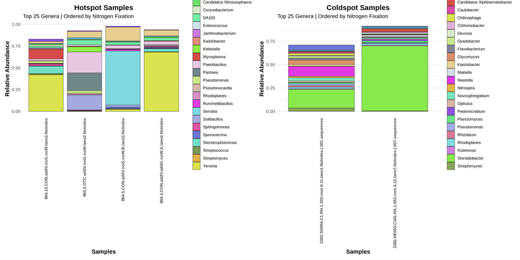

```r
# ===========================
# ✅ 3) Combine Side by Side
# ===========================
combined_composition <- p_hotspot + p_coldspot
print(combined_composition)
```

```r
ggsave("hotspot_coldspot_composition.png", combined_composition,
       width = 16, height = 8, dpi = 300, bg = "white")
```

## 6. Alpha Diversity Analysis

We compare alpha diversity between hotspot and coldspot communities to understand diversity patterns in relation to nitrogen fixation potential.

```r
# ===========================
# Prepare phyloseq subsets (all genera)
# ===========================
hotspot_samples <- hotspot_df %>%
  filter(Hotspot == "Hot Spot (p<0.05)") %>%
  pull(`#SampleID`)

coldspot_samples <- hotspot_df %>%
  filter(Hotspot == "Cold Spot (p<0.05)") %>%
  pull(`#SampleID`)

ps_hotspots <- prune_samples(hotspot_samples, ps_soil) %>%
  prune_taxa(taxa_sums(.) > 0, .)

ps_coldspots <- prune_samples(coldspot_samples, ps_soil) %>%
  prune_taxa(taxa_sums(.) > 0, .)

ps_hotcold <- merge_phyloseq(ps_hotspots, ps_coldspots)

sample_data(ps_hotcold)$Hotspot_Status <- ifelse(
  sample_names(ps_hotcold) %in% hotspot_samples, "Hotspot", "Coldspot"
)

cat("Diversity analysis dataset:", nsamples(ps_hotcold), "samples\n")
```

```
## Diversity analysis dataset: 6 samples
```

### 6.1 Shannon Diversity Comparison

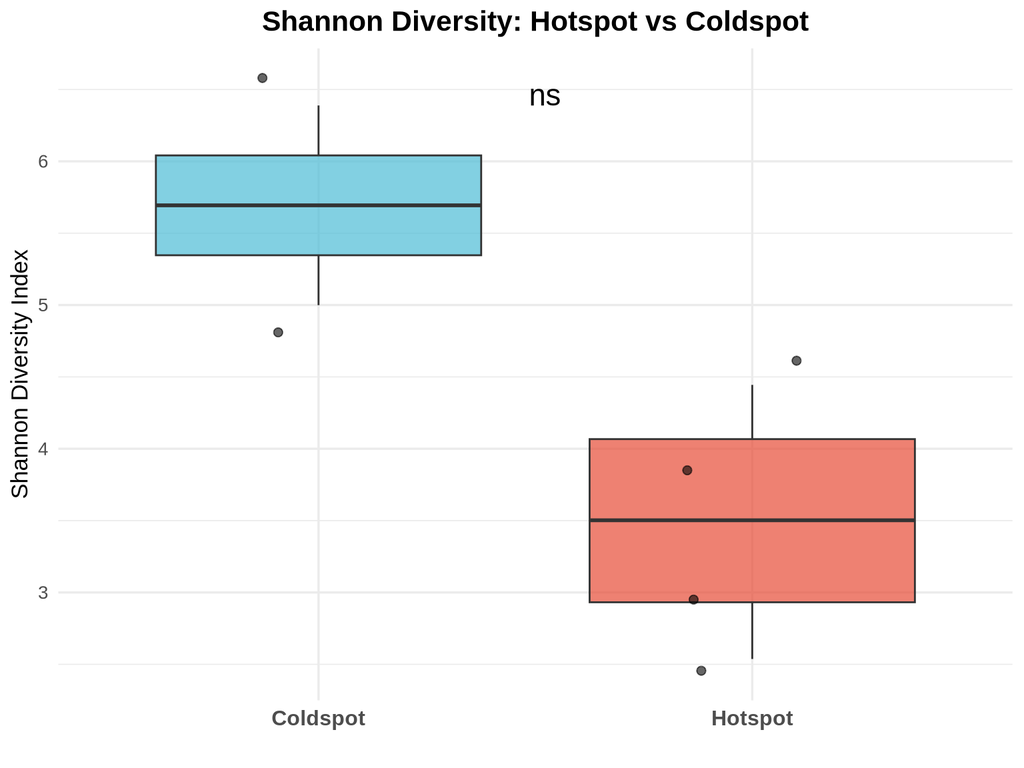

```r
# ===========================
# Shannon Diversity Boxplot + Wilcox Test
# ===========================
shannon_df <- estimate_richness(ps_hotcold, measures = "Shannon") %>%
  mutate(SampleID = rownames(.)) %>%
  left_join(hotspot_df %>% select(`#SampleID`, Hotspot),
            by = c("SampleID" = "#SampleID")) %>%
  mutate(Hotspot = ifelse(Hotspot == "Hot Spot (p<0.05)", "Hotspot", "Coldspot"))

p_diversity <- ggplot(shannon_df, aes(x = Hotspot, y = Shannon, fill = Hotspot)) +
  geom_boxplot(alpha = 0.7, outlier.shape = 21, outlier.fill = "white", outlier.color = "black") +
  geom_jitter(width = 0.15, size = 2, alpha = 0.6) +
  scale_fill_manual(values = c("Hotspot" = "#E64B35FF", "Coldspot" = "#4DBBD5FF")) +
  theme_minimal(base_size = 13) +
  labs(
    title = "Shannon Diversity: Hotspot vs Coldspot",
    x = "",
    y = "Shannon Diversity Index"
  ) +
  theme(
    plot.title = element_text(hjust = 0.5, face = "bold", size = 16),
    legend.position = "none",
    axis.text.x = element_text(face = "bold", size = 12)
  ) +
  stat_compare_means(method = "wilcox.test", label = "p.signif", label.x = 1.5, size = 6)

print(p_diversity)
```

```r
ggsave("shannon_diversity_comparison.png", p_diversity,
       width = 8, height = 6, dpi = 300, bg = "white")
```

## 7. Community Ordination Analysis

We use Non-metric Multidimensional Scaling (NMDS) to visualize community structure differences between hotspot and coldspot samples.

```r
# ===========================
# ✅ 3) NMDS Ordination (Bray-Curtis)
# ===========================
# Transform to relative abundance for NMDS
ps_rel <- transform_sample_counts(ps_hotcold, function(x) x / sum(x))

# NMDS with Bray-Curtis distance
ord_nmds <- ordinate(ps_rel, method = "NMDS", distance = "bray")
```

```
## *** Best solution was not repeated -- monoMDS stopping criteria:
##      6: no. of iterations >= maxit
##     11: stress < smin
##      1: stress ratio > sratmax
##      2: scale factor of the gradient < sfgrmin
```

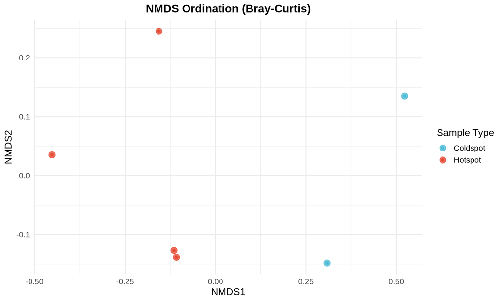

```r
# Plot NMDS
p_nmds <- plot_ordination(ps_rel, ord_nmds, color = "Hotspot_Status") +
  geom_point(size = 4, alpha = 0.8) +
  #stat_ellipse(aes(color = Hotspot_Status), type = "t", level = 0.95, linewidth = 1) +
  scale_color_manual(values = c("Hotspot" = "#E64B35FF", "Coldspot" = "#4DBBD5FF")) +
  theme_minimal(base_size = 14) +
  labs(
    title = "NMDS Ordination (Bray-Curtis)",
    color = "Sample Type"
  ) +
  theme(plot.title = element_text(hjust = 0.5, face = "bold", size = 16))

print(p_nmds)
```

```r
ggsave("nmds_ordination.png", p_nmds,
       width = 10, height = 6, dpi = 300, bg = "white")
```

## 8. Results Summary and Data Export

```r
# ===========================
# 8) Summary Statistics and Save Outputs
# ===========================
# Print summary statistics
cat("\n=== ANALYSIS SUMMARY ===\n")
```

```
##
## === ANALYSIS SUMMARY ===
```

```r
cat("Total samples:", nrow(sf_data), "\n")
```

```
## Total samples: 251
```

```r
cat("Nitrogen fixation range:", round(range(sf_data$NitrogenFix), 3), "\n")
```

```
## Nitrogen fixation range: -2.483 11.755
```

```r
cat("Hot spots (p<0.05):", sum(sf_data$Hotspot == "Hot Spot (p<0.05)"), "\n")
```

```
## Hot spots (p<0.05): 4
```

```r
cat("Cold spots (p<0.05):", sum(sf_data$Hotspot == "Cold Spot (p<0.05)"), "\n")
```

```
## Cold spots (p<0.05): 2
```

```r
cat("Geographic extent:", round(bbox, 2), "\n")
```

```
## Geographic extent: -160.25 -33.83 158.42 75.16
```

```r
# Save outputs
writeRaster(idw_map, "EMP_NitrogenFix_Interpolated.tif", overwrite = TRUE)
st_write(sf_data, "EMP_NitrogenFix_Hotspots.shp", delete_layer = TRUE)
```

```
## Deleting layer `EMP_NitrogenFix_Hotspots' using driver `ESRI Shapefile'
## Writing layer `EMP_NitrogenFix_Hotspots' to data source
##   `EMP_NitrogenFix_Hotspots.shp' using driver `ESRI Shapefile'
## Writing 251 features with 4 fields and geometry type Point.
```

```r
cat("\nAnalysis completed successfully. All outputs saved.\n")
```

```
##
## Analysis completed successfully. All outputs saved.
```

## Conclusions

This workflow provides a template for spatial microbiome analysis that can be adapted to real functional predictions and environmental gradients in microbial ecology research.

## Technical Notes

- **Coordinate System**: WGS84 (EPSG:4326)
- **Interpolation Method**: Inverse Distance Weighting (IDW) with power = 2
- **Spatial Statistics**: Getis-Ord Gi* with k=4 nearest neighbors
- **Statistical Testing**: Wilcoxon rank-sum test for diversity comparisons
- **Ordination Method**: NMDS with Bray-Curtis dissimilarity

**Software Versions**: R 4.3+, phyloseq 1.44+, terra 1.7+, sf 1.0+